# Normalization performance report

## Normalized probe associations with measured batch variables

The most variable normalized probes were extracted, decomposed into principal components and each component regressed against each batch variable. If the normalization has performed well then there will be no associations between normalized probe PCs and batch variables. Horizontal dotted line denotes \(p = 0.05\) in log-scale.

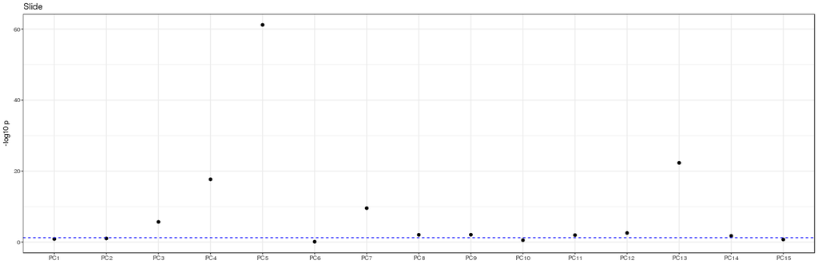

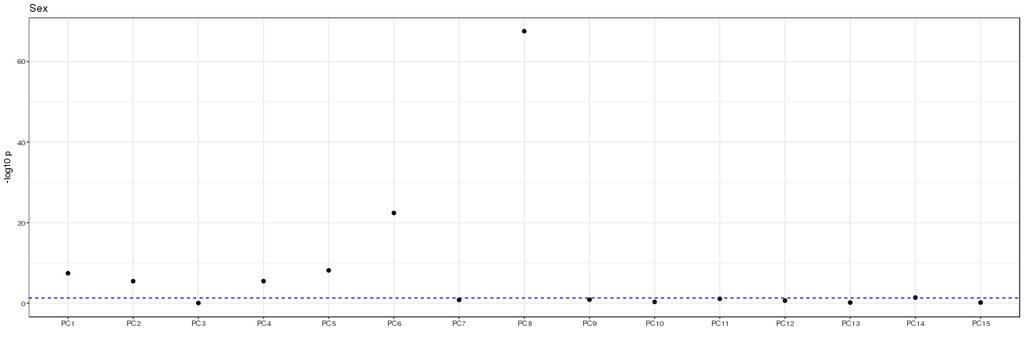

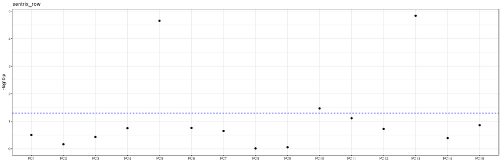

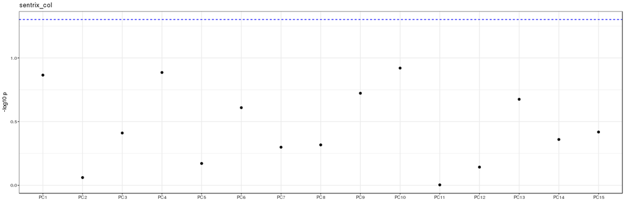

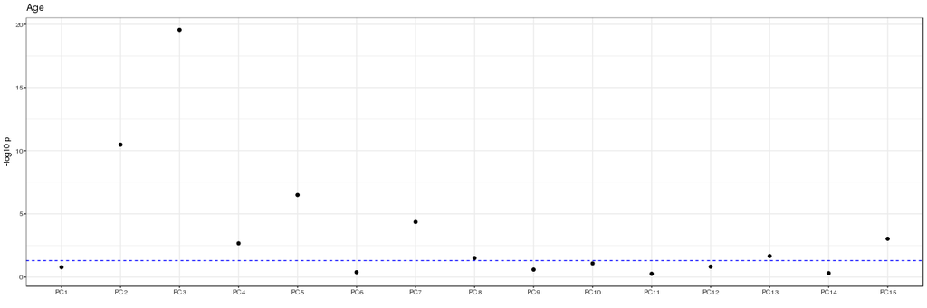

The following plots show regression coefficients when each principal component is regressed against each batch variable level along with 95% confidence intervals. Cases significantly different from zero are coloured red (p < 0.01, t-test).

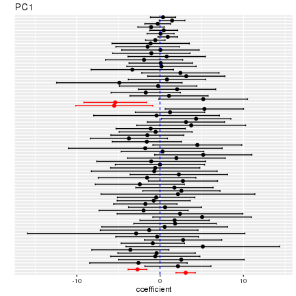

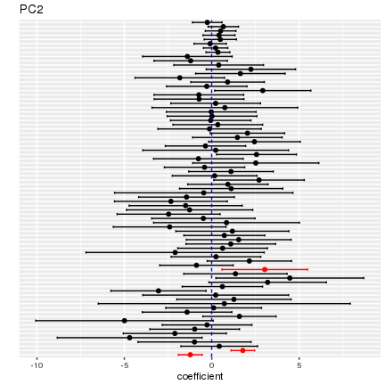

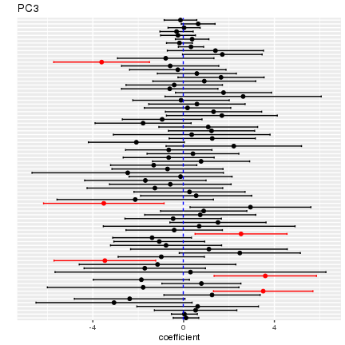

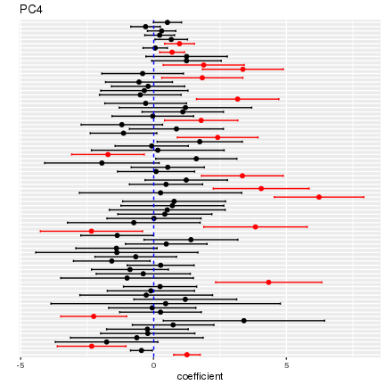

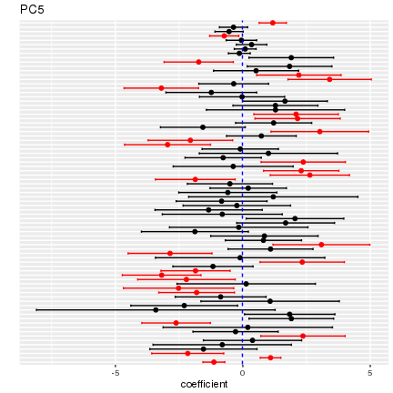

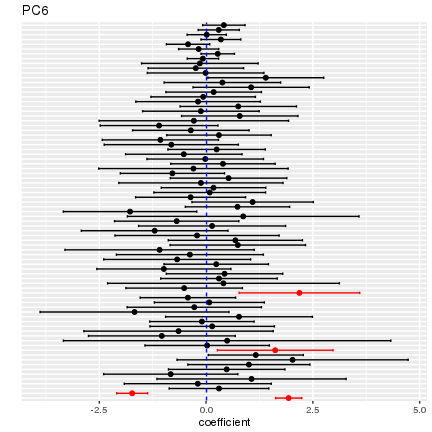

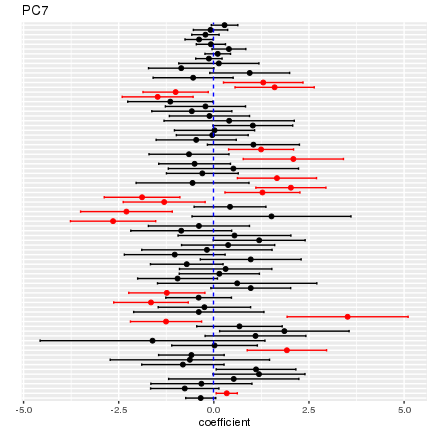

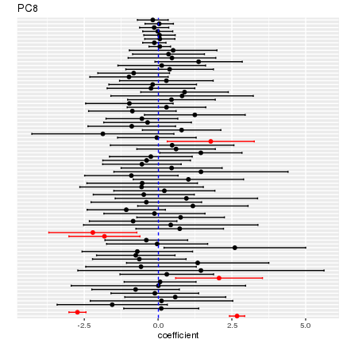

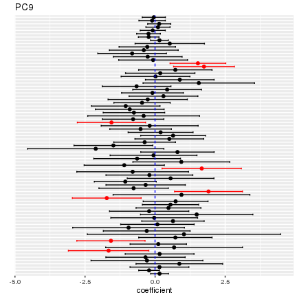

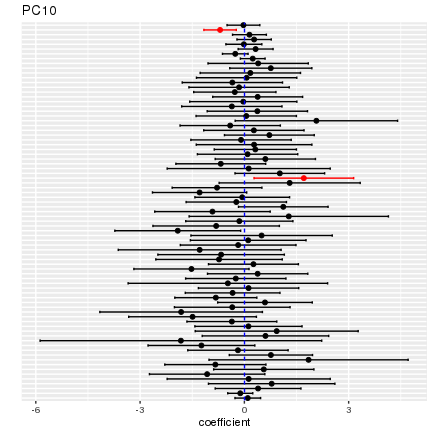

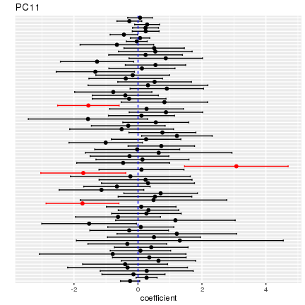

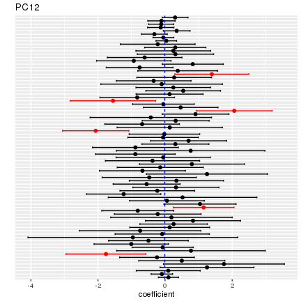

[3 more figures not shown]

| batch.variable | batch.value | principal.component | test | p.value | estimate | lower | upper |
| --- | --- | --- | --- | --- | --- | --- | --- |
| Slide | 3999997048 | PC1 | t-test | 7.59e-03 | -5.511 | -10.1187 | -0.902 |
| Slide | 3999997053 | PC1 | t-test | 1.43e-03 | -5.389 | -9.1539 | -1.623 |
| Sex |  | PC1 | F-test | 3.75e-08 | 31.260 |  |  |
| Sex | F | PC1 | t-test | 1.29e-08 | 3.065 | 1.9032 | 4.227 |
| Sex | M | PC1 | t-test | 2.45e-07 | -2.717 | -3.8457 | -1.588 |
| Slide | 3999984050 | PC2 | t-test | 5.74e-03 | 3.031 | 0.5824 | 5.480 |
| Sex |  | PC2 | F-test | 3.54e-06 | 21.997 |  |  |
| Sex | F | PC2 | t-test | 8.45e-05 | -1.228 | -1.9064 | -0.549 |
| Sex | M | PC2 | t-test | 1.81e-08 | 1.778 | 1.1027 | 2.454 |
| Age |  | PC2 | F-test | 3.31e-11 | 46.065 |  |  |
| Slide |  | PC3 | F-test | 2.06e-06 | 2.163 |  |  |
| Slide | 3999979011 | PC3 | t-test | 3.64e-04 | 3.508 | 1.3175 | 5.698 |
| Slide | 3999984024 | PC3 | t-test | 3.82e-04 | 3.600 | 1.3437 | 5.855 |
| Slide | 3999984039 | PC3 | t-test | 5.65e-04 | -3.470 | -5.7108 | -1.228 |
| Slide | 3999984055 | PC3 | t-test | 5.30e-03 | 2.530 | 0.5055 | 4.556 |
| Slide | 3999984115 | PC3 | t-test | 3.13e-03 | -3.517 | -6.1719 | -0.861 |
| Slide | 3999997147 | PC3 | t-test | 1.40e-04 | -3.613 | -5.7228 | -1.503 |
| Age |  | PC3 | F-test | 2.73e-20 | 93.108 |  |  |
| Slide |  | PC4 | F-test | 2.12e-18 | 3.944 |  |  |
| Slide | 3999979001 | PC4 | t-test | 6.25e-05 | -2.329 | -3.6214 | -1.037 |
| Slide | 3999979036 | PC4 | t-test | 5.34e-05 | -2.253 | -3.4908 | -1.015 |
| Slide | 3999984041 | PC4 | t-test | 1.55e-06 | 4.333 | 2.3366 | 6.330 |
| Slide | 3999984079 | PC4 | t-test | 6.64e-03 | -2.338 | -4.2611 | -0.415 |
| Slide | 3999984115 | PC4 | t-test | 1.22e-05 | 3.835 | 1.8899 | 5.781 |
| Slide | 3999984146 | PC4 | t-test | 1.07e-15 | 6.229 | 4.5471 | 7.911 |
| Slide | 3999984150 | PC4 | t-test | 6.73e-07 | 4.052 | 2.2483 | 5.855 |
| Slide | 3999984154 | PC4 | t-test | 1.44e-06 | 3.345 | 1.8090 | 4.881 |
| Slide | 3999984166 | PC4 | t-test | 5.09e-03 | -1.715 | -3.0808 | -0.349 |
| Slide | 3999997048 | PC4 | t-test | 3.95e-04 | 2.414 | 0.8977 | 3.931 |
| Slide | 3999997071 | PC4 | t-test | 3.71e-03 | 1.793 | 0.4151 | 3.171 |

[output cut: 150 more lines]